# L04 ggplot III

Data Visualization (STAT 302)

Jingyang Zhang

# Overview

The goal of this lab is to continue the process of unlocking the power of `ggplot2` through constructing and experimenting with a few basic plots.

# Datasets

We’ll be using data from the `blue_jays.rda`, `tech_stocks.rda`, `corruption.rda`, and `cdc.txt` datasets which are already in the `/data` subdirectory in our **data_vis_labs** project.

```r
# Load package(s)
library(tidyverse)
library(lubridate)

library(ggrepel)


# Load datasets
load("data/blue_jays.rda")

load("data/tech_stocks.rda")

load("data/corruption.rda")

# Read in the cdc dataset
cdc <- read_delim(file = "data/cdc.txt", delim = "|") %>%
  mutate(genhlth = factor(genhlth,
    levels = c("excellent", "very good", "good", "fair", "poor")
  ))
```

# Exercises

Complete the following exercises.

### Exercise 1

Using `blue_jays.rda` dataset, recreate the following graphic as precisely as possible.

*Hints:*

- Transparency is 0.6
- Point size 2
- Shift text horizontally by 0.5
- See pg 44 in *ggplot2*

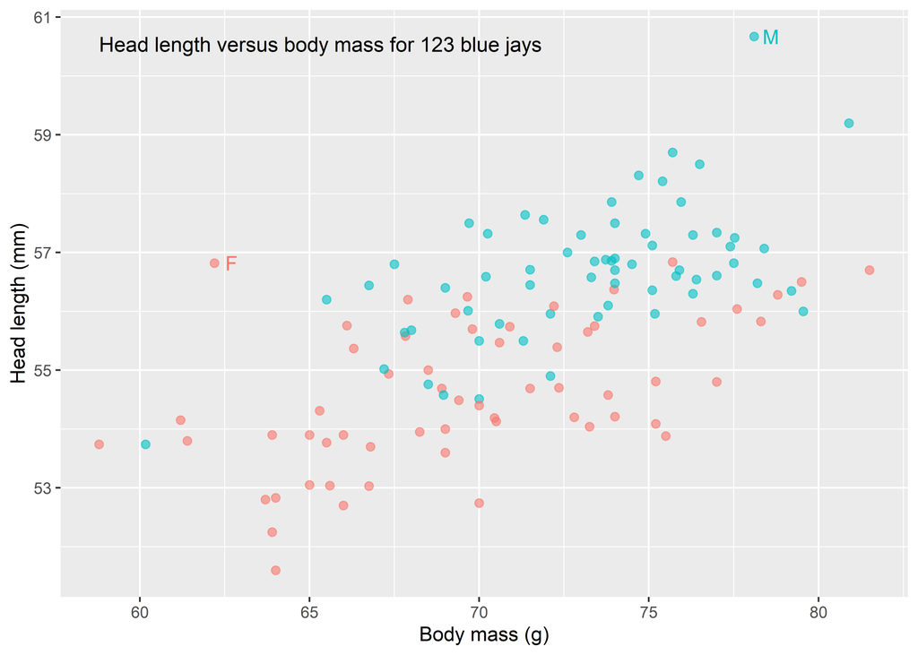

```r
# label data

## c(): concatenate function
label_info <- blue_jays %>%
  filter(BirdID %in% c('1142-05914', '702-90567'))

# location info for annotation
xrng <- range(blue_jays$Mass)
yrng <- range(blue_jays$Head)
caption <- "Head length versus body mass for 123 blue jays"

ggplot(blue_jays, aes(Mass, Head, color = KnownSex))+
  geom_point(alpha = 0.6, size = 2,
             show.legend = FALSE)+
  geom_text(data = label_info,
            aes(label = KnownSex),
            nudge_x = 0.5,
            show.legend = FALSE)+
  annotate("text", x = xrng[1], y = yrng[2],
# placement of anchor point, the default is hjust=0.5, vjust=0.5
           label = caption,
           hjust = 0, vjust = 1,
# this reset the anchor point to the upper left corner, now the upper left corner is set to the (x,y)
           size = 4)+
  labs(x = "Body mass (g)", y = "Head length (mm)")
```

Notes 1. As text and points share colors, thus the color aesthetic is shared -> indicating the color aesthetic should be at the top layer

### Exercise 2

Using `tech_stocks` dataset, recreate the following graphics as precisely as possible.

##### Plot 1

*Hints:*

- serif font

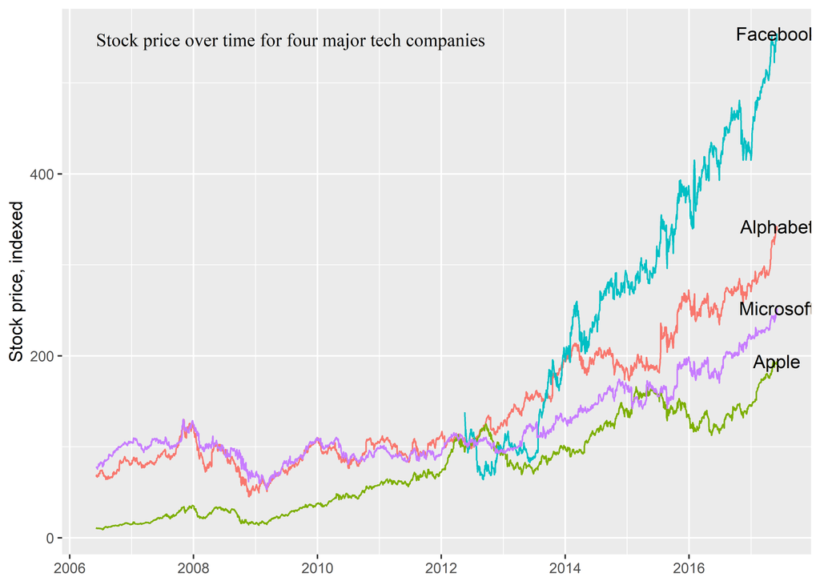

```r
yrng <- range(tech_stocks$price_indexed)

xrng <- range(tech_stocks$date)

caption <- "Stock price over time for four major tech companies"




ggplot(tech_stocks, aes(date, price_indexed, color = company))+
  geom_line()+
  geom_text(data = subset(tech_stocks,
            date == xrng[2]), aes(label = company),
            size = 4, color = "black", nudge_x = -0.5)+
  annotate("text", x = xrng[1], y = yrng[2],
           label = caption, hjust = 0, vjust = 1,
           size = 4, family = "serif")+
  labs(x = NULL, y = "Stock price, indexed")+
  theme(legend.position = "none")
```

##### Plot 2

*Hints:*

- Package `ggrepel`
- `box.padding` is 0.6
- Minimum segment length is 0
- Horizontal justification is to the right
- seed of 9876

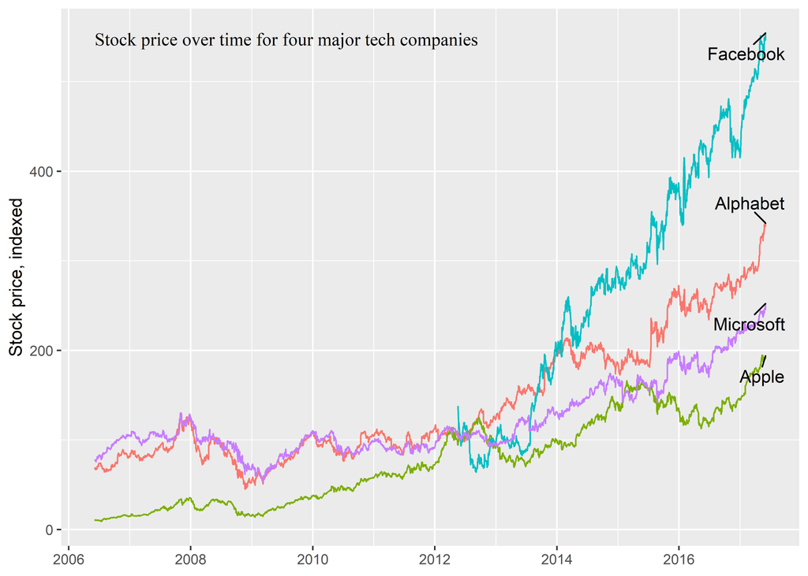

```r
ggplot(tech_stocks, aes(date, price_indexed, color = company))+
  geom_line()+
  geom_text_repel(aes(label = company), data = subset(tech_stocks, date == xrng[2]),
hjust = 1, box.padding = 0.6, color = "black",
segment.colour = "black", min.segment.length = 0, show.legend = NA, seed = 9876)+
  annotate("text", x = xrng[1], y = yrng[2],
           label = caption, hjust = 0, vjust = 1, size = 4, family = "serif")+
  labs(x = NULL, y = "Stock price, indexed")+
  theme(legend.position = "none")
```

### Exercise 3

Using `corruption.rda` dataset, recreate the following graphic as precisely as possible.

*Hints:*

- Transparency is 0.6
- Only use 2015 data
- Color used is `grey60`
- `"y ~ log(x)"` (method `"lm"`)
- Package `ggrepel`
- `box.padding` is 0.6
- Minimum segment length is 0
- seed is 9876

[figure not shown]

```r
corr_sub <- corruption %>%
  filter(year == 2015) %>%
  filter((cpi > 50 & country %in% c("Chile", "Japan", "United States", "Singapore")) | (cpi < 50 & country %in% c("Ghana", "Argentina", "Iraq", "Niger", "China")))

xrng <- range(corruption$cpi)
yrng <- range(corruption$hdi)


ggplot(subset(corruption, year == 2015),
       aes(cpi, hdi,color = region))+
  geom_point(alpha = 0.6)+
  geom_smooth(aes(group = 1), method = "lm",
              formula = y~log(x), se = FALSE, color = "grey60")+
  geom_text_repel(aes(label = country), data = corr_sub, box.padding = 0.6, color = "black",
              segment.colour = "black",
              min.segment.length = 0,show.legend = NA,
              seed = 9876)+
  annotate("text", x = xrng[1], y = yrng[2], label = caption, hjust = 0, vjust = 1, size = 4)+
  labs(x = "Corruption Perceptions Index, 2015 (100=least corrupt)", y = "Human Development Index, 2015\n (1.0=most developed)")+
  ggtitle("Corruption and human development (2015)")
```

### Exercise 4

Using `cdc` dataset, recreate the described graphic as precisely as possible.

Using Bilbo Baggins’ responses below to the CDC BRSFF questions, add Bilbo’s data point as a transparent (0.5) solid red circle of size 4 to a scatterplot of `weight` by `height` with transparent (0.1) solid blue circles of size 2 as the plotting characters. In addition, label the point with his name in red. Left justify and rotate the label so it reads vertically from bottom to top — shift it up by 10 pounds too. Plot should use appropriately formatted axis labels. Remember that the default shape is a solid circle.

- `genhlth` - How would you rate your general health? **fair**
- `exerany` - Have you exercised in the past month? **1=yes**
- `hlthplan` - Do you have some form of health coverage? **0=no**
- `smoke100` - Have you smoked at least 100 cigarettes in your life time? **1=yes**
- `height` - height in inches: **46**
- `weight` - weight in pounds: **120**
- `wtdesire` - weight desired in pounds: **120**
- `age` - in years: **45**
- `gender` - m for males and f for females: **m**

Add data

```r
bilbo <- data.frame("fair", 1, 0,1,46,120,120,45,"m")
names(bilbo) = c("genhlth", "exerany", "hlthplan", "smoke100", "height", "weight", "wtdesire", "age", "gender")
```

Plot

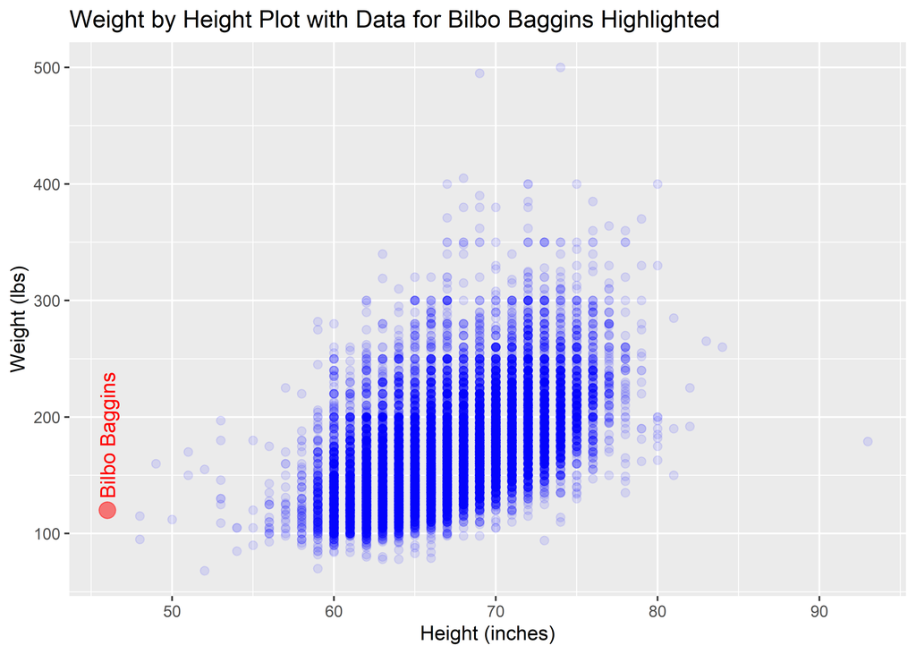

```r
ggplot(cdc, aes(height, weight))+
  geom_point(color = "blue", alpha = 0.1, size = 2)+
  geom_point(data = bilbo, color = "red",
             size = 4, alpha = 0.5)+
  annotate("text", x = bilbo$height, y = bilbo$weight+10,  label = "Bilbo Baggins",
           hjust = 0, size = 4,
           color = "red", angle = 90)+
  labs(x = "Height (inches)", y = "Weight (lbs)")+
  ggtitle("Weight by Height Plot with Data for Bilbo Baggins Highlighted")
```

*Hint:* Create a new dataset (maybe call it `bilbo` or `bilbo_baggins`) using either `data.frame()` (base R - example in book) or `tibble()` (tidyverse - see help documentation for the function). Make sure to use variable names that exactly match `cdc`’s variable names.

# Class Notes

1. Each layer in ggplot can has its own data
2. We can provide the text layer its own data
3. Inheritance only comes from `ggplot()` layer